# TALL_MODIS_LAI

John W Smith

2/3/2022

## MODIS LAI

In this document we will extract data on Leaf Area Index (LAI) from MODIS data for Talladega National Forest.

The MODIS LAI data for Talladega can be obtained from their website (https://modis.ornl.gov/sites/?id=us_alabama_neon_tall), I have elected not to include it here as it requires an account to download and I do not want to distribute their data without proper permission. In particular, the LAI data that we will be examining is the `filtered_scaled_LAI_500m` dataset.

Let’s start by reading in the data.

```r
modis_LAI <- read.csv('./filtered_scaled_Lai_500m.csv', header = FALSE)
dim(modis_LAI)
```

```
## [1] 1796  294
```

The dataset has 1796 observations of LAI, averaged over 4 day periods. For a detailed understanding of the columns of the dataframe that we read in, one can be found here: https://lpdaac.usgs.gov/documents/624/MOD15_User_Guide_V6.pdf

```r
## qa_qc_filter:
## Inputs: x, threshold
## x: numeric vector
## threshold: minimum proportion of non-NA values
qa_qc_filter <- function(x, threshold = .5){
  N <- length(x)
  n <- length(which(is.na(x)))
  if ((n/N) <= threshold){
    s <- mean(x, na.rm = TRUE)
  } else{
    s <- NA
  }
  return(s)
}
```

Now that we have a filter, let’s use it to extract the LAI for Talladega.

```r
## force entries to be numeric - they are read in as characters
modis_LAI[,6:ncol(modis_LAI)] <- as.numeric(as.matrix(modis_LAI[,6:ncol(modis_LAI)]))
```

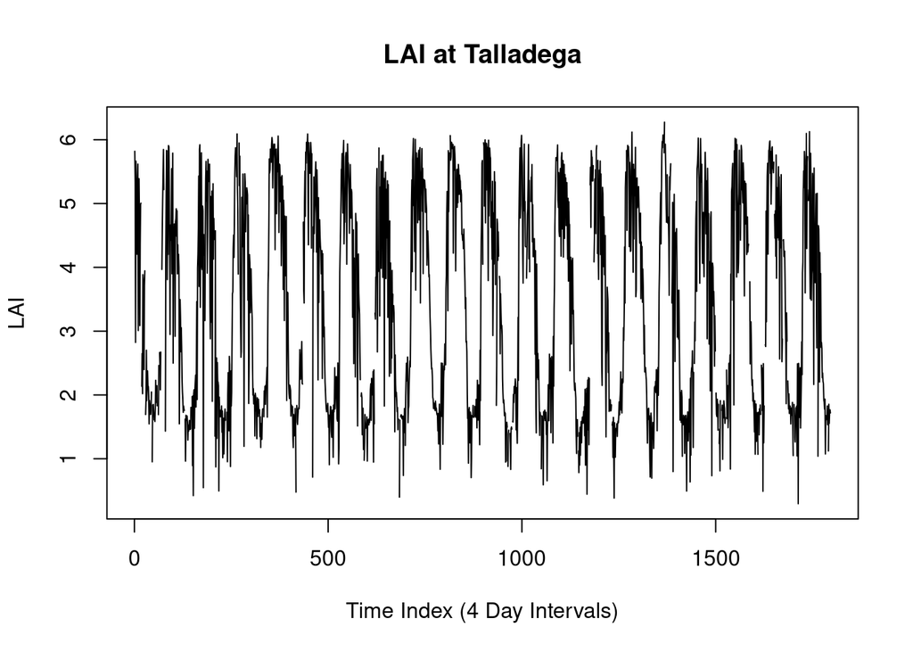

```r
## allocate space for the Julian 'AYYYYDDD' format and the mean LAI value subject to filtering
LAI_date <- rep(0, nrow(modis_LAI))
LAI_val <- rep(0, nrow(modis_LAI))

## extract LAI values
for (i in 1:nrow(modis_LAI)){
  LAI_date[i] <- modis_LAI$V3[i]
  LAI_val[i] <- qa_qc_filter(x = as.numeric(modis_LAI[i, 6:ncol(modis_LAI)]), threshold = .8)
}

plot(LAI_val, type = 'l', xlab = 'Time Index (4 Day Intervals)', ylab = 'LAI', main = 'LAI at Talladega')
```